# Final Project

# Predictive Tasks

## Decision Trees

partition the data

```r
data$Country = as.factor(data$Country)
data$Year = as.numeric(data$Year)


data$Life <- data$`Life expectancy`
data$infantmort <- cut(data$`infant deaths`,
                              breaks = 3,
                              labels=c('low_infant', 'middle_infant', 'high_infant'))
data$expenditure <- cut(data$`Total expenditure`,
                              breaks = 3,
                              labels=c('low_expenditure','med_expenditure', 'high_expenditure'))
data$pop <- cut(data$Population,
                              breaks = 3,
                              labels=c('low_pop','med_pop', 'high_pop'))
data$bmi <- cut(data$BMI,
                              breaks = 3,
                              labels=c('low_BMI','med_BMI', 'high_BMI'))
data$gdp <- cut(data$GDP,
                              breaks = 3,
                              labels=c('low_GDP','med_GDP', 'high_GDP'))
data$alcohol <- cut(data$Alcohol,
                              breaks = 3,
                              labels=c('low_alc','med_alc', 'high_alc'))
summary(data$Year)
```

```
##    Min. 1st Qu.  Median    Mean 3rd Qu.    Max.
##    2000    2004    2008    2008    2012    2015
```

```r
data$Year <- cut(data$Year,
                              breaks = c(-Inf,2007, Inf),
                              labels=c("2000", "2007"))
summary(data$Year)
```

```
## 2000 2007
## 1464 1474
```

```r
# data$Year <- cut(data$Year, breaks=c(-Inf, 2007, Inf), labels = c('2000-2007', '2007-2015'))

drops <- c("Alcohol",
           "percentage expenditure",
           "BMI",
           "GDP",
           "Diphtheria",
           "Life expectancy",
           "Measles",
           "infant deaths",
           "Total expenditure",
           "thinness  1-19 years",
           "thinness 5-9 years",
           "Population",
           "HIV/AIDS",
           "Polio",
           "under-five deaths",
           "Adult Mortality",
           "Income composition of resources",
           "Schooling",
           "Country")

data <- data[ , !(names(data) %in% drops)]
data <- data %>% drop_na
```

Decision Tree with one ensemble method Training and Testing Data Divide the data into 75% training, 25% test

```r
train_rows = sample(1:nrow(data), 0.75*nrow(data))
train = data[train_rows, ]
test = data[-train_rows, ]
```

Decision Tree (using regression):

The automatic cost complexity of the tree shows diminishing returns after 6 terminal nodes (which you can see in the cp, X-val Relative Error plot below the trees).

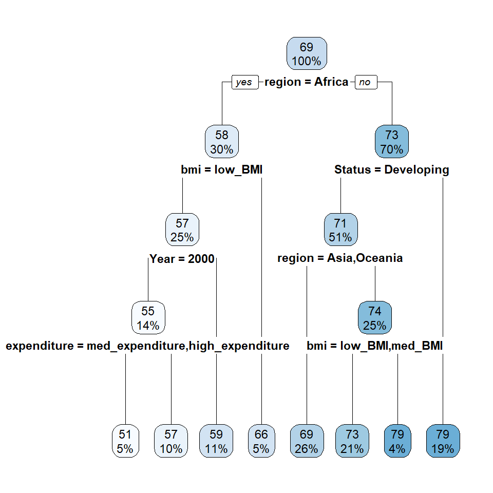

```r
m1 <- rpart(
  formula = Life ~ .,
  data = train,
 #cp = 0.01,
  method = "anova"
)

rpart.plot(m1)
```

Plot the tree that includes the observation number within each node:

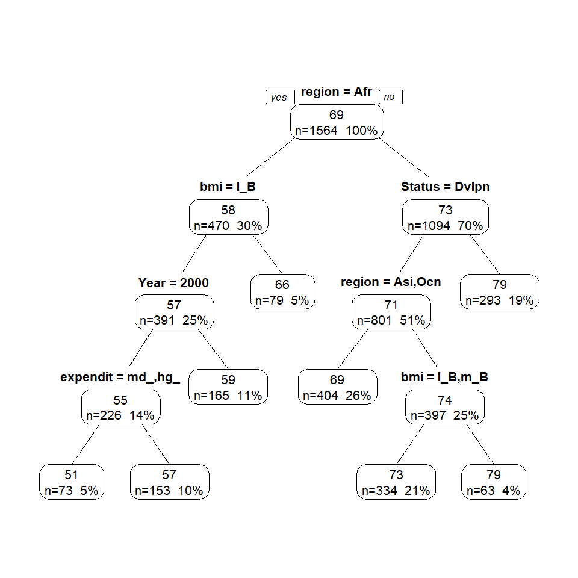

```r
prp(m1, type = 1, extra = 101, roundint = FALSE)
```

# In the plot, y-axis is cross validation error, lower x-axis is cost complexity (α or cp) value, upper x-axis is the number of terminal nodes (tree size)

We find diminishing returns after 6 terminal (leaf) nodes at a cost complexity parameter (cp) of .012. You may also notice the dashed line which goes through the terminal node, tree size= 5.

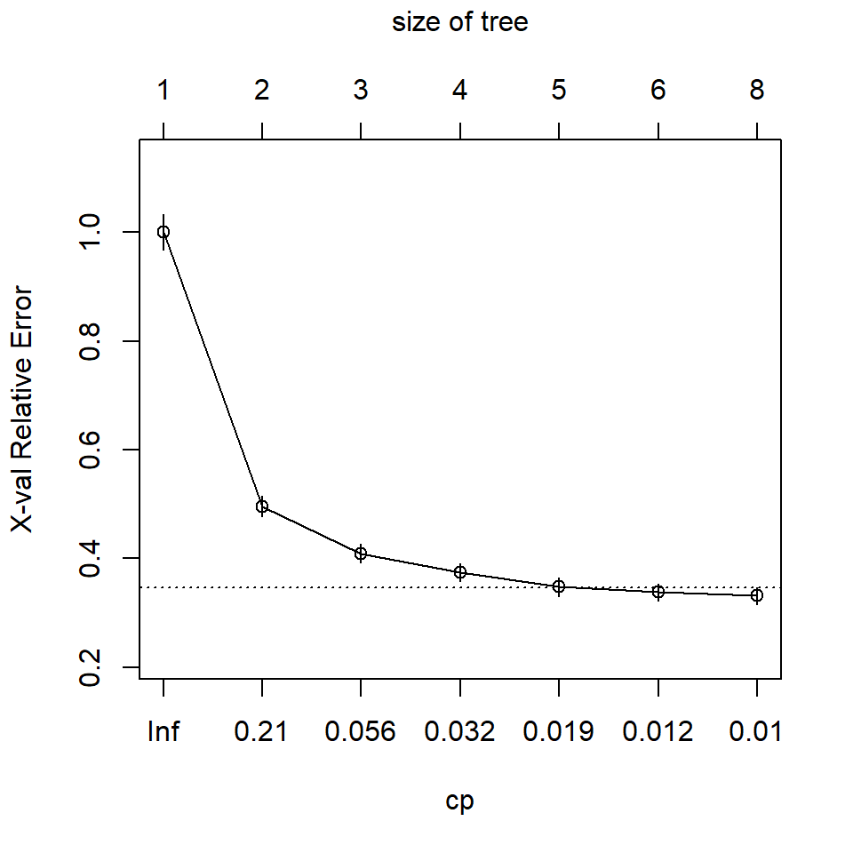

```r
plotcp(m1)
```

To show the value of a 6 leaf node tree, we can see the plot below to review the diminishing returns as the tree continues to grow.

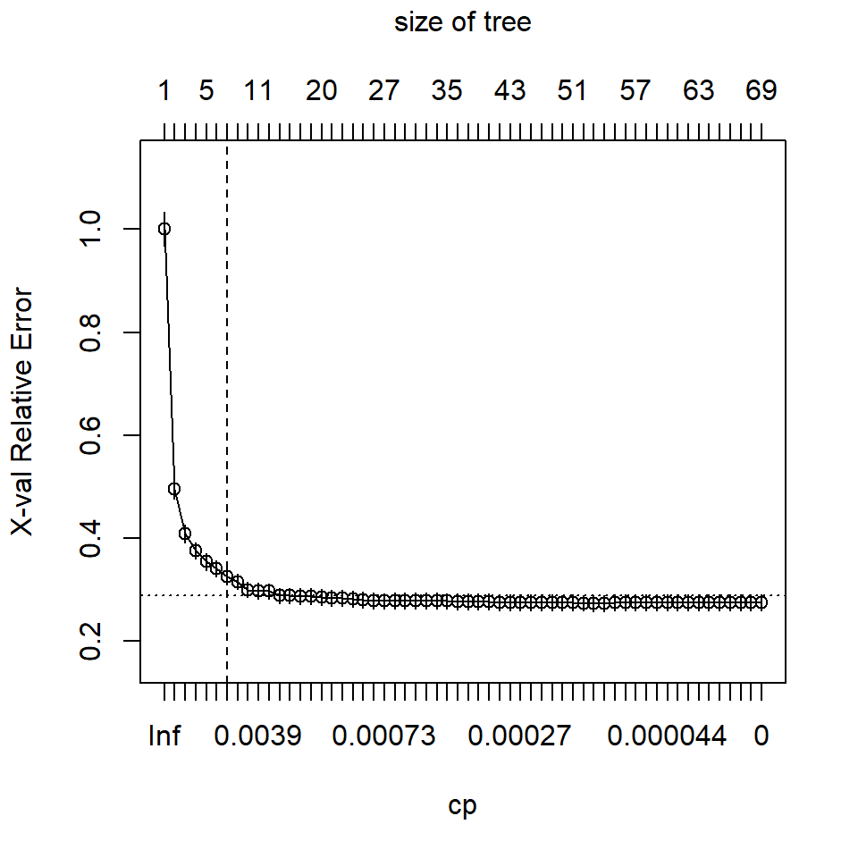

```
## integer(0)
```

```r
m2 <- rpart(
   formula = Life ~ .,
   data    = train,
   method  = "anova",
   control = list(cp = 0, xval = 10)
 )

plotcp(m2) +
abline(v = 7, lty = "dashed")
```

```r
#rpart.plot(m2)
```

Now we can review combinations of determining factors with the results from our regression trees by using different modeling examples.

We use a minimum spit of 5 and a maximum depth of 6 to match our splits and provide room for our terminal nodes.

```r
m3 <- rpart(
  formula = Life ~ .,
  data = train,
  method = "anova",
  control = list(minsplit = 5, maxdepth = 6, xval = 10)
)

m3$cptable
```

```
##           CP nsplit rel error    xerror       xstd
## 1 0.50517378      0 1.0000000 1.0012181 0.03324759
## 2 0.08676859      1 0.4948262 0.4962860 0.01882339
## 3 0.03631538      2 0.4080576 0.4096466 0.01724082
## 4 0.02773289      3 0.3717422 0.3753380 0.01621807
## 5 0.01346604      4 0.3440094 0.3480682 0.01640391
## 6 0.01080921      5 0.3305433 0.3359506 0.01586835
## 7 0.01000000      7 0.3089249 0.3308425 0.01560777
```

Then we search the grid, prividing room for our splits and leaf nodes in our ranges. The results show 91 different combinations, requiring 91 different models.

```r
hyper_grid <- expand.grid(
   minsplit = seq(3, 15, 1),
   maxdepth = seq(6, 12, 1)
 )
 head(hyper_grid)
```

```
##   minsplit maxdepth
## 1        3        6
## 2        4        6
## 3        5        6
## 4        6        6
## 5        7        6
## 6        8        6
```

```r
 tail(hyper_grid)
```

```
##    minsplit maxdepth
## 86       10       12
## 87       11       12
## 88       12       12
## 89       13       12
## 90       14       12
## 91       15       12
```

```r
 nrow(hyper_grid)
```

```
## [1] 91
```

Now we can automate the modeling and save each model into its own item list.

```r
 models <- list()
 for (i in 1:nrow(hyper_grid)) {

   # get minsplit, maxdepth values at row i
   minsplit <- hyper_grid$minsplit[i]
   maxdepth <- hyper_grid$maxdepth[i]

   # train a model and store in the list
   models[[i]] <- rpart(
     formula = Life ~ .,
     data    = train,
    method  = "anova",
    control = list(minsplit = minsplit, maxdepth = maxdepth)
   )
 }
```

```r
get_cp <- function(x) {
   min    <- which.min(x$cptable[, "xerror"])
   cp <- x$cptable[min, "CP"]
 }

get_min_error <- function(x) {
  min    <- which.min(x$cptable[, "xerror"])
  xerror <- x$cptable[min, "xerror"]
}
hyper_grid %>%
   mutate(cp    = purrr::map_dbl(models, get_cp),
          error = purrr::map_dbl(models, get_min_error)) %>%
   arrange(error) %>%
   top_n(-6, wt = error)
```

```
##   minsplit maxdepth   cp     error
## 1       15        8 0.01 0.3208260
## 2       15       10 0.01 0.3227785
## 3        8        8 0.01 0.3238369
## 4       12        6 0.01 0.3241669
## 5        6        9 0.01 0.3244774
## 6        5        8 0.01 0.3250152
```

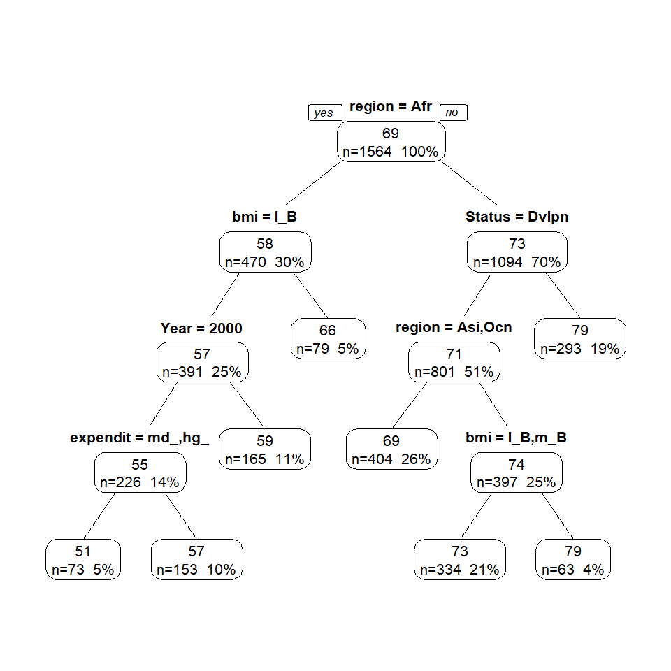

```r
optimal_tree <- rpart(
   formula = Life ~ .,
   data    = train,
   method  = "anova",
   control = list(minsplit = 10, maxdepth = 15, cp = 0.01)
 )
prp(optimal_tree, type=1, extra=101, roundint = FALSE)
```

```r
 pred <- predict(optimal_tree, newdata = test)
 # pred
```

```r
  RMSE(pred = pred, obs = test$Life)
```

```
## [1] 5.109755
```

Some interesting rules from the decision tree

```r
rpart.rules(optimal_tree, cover = TRUE)
```

```
##  Life                                                                                                                                                                                cover
##    51 when region is                                Africa & bmi is             low_BMI                        & Year is 2000 & expenditure is med_expenditure or high_expenditure      5%
##    57 when region is                                Africa & bmi is             low_BMI                        & Year is 2000 & expenditure is                     low_expenditure     10%
##    59 when region is                                Africa & bmi is             low_BMI                        & Year is 2007                                                          11%
##    66 when region is                                Africa & bmi is med_BMI or high_BMI                                                                                                 5%
##    69 when region is                       Asia or Oceania                              & Status is Developing                                                                         26%
##    73 when region is                    Americas or Europe & bmi is  low_BMI or med_BMI & Status is Developing                                                                         21%
##    79 when region is                    Americas or Europe & bmi is            high_BMI & Status is Developing                                                                          4%
##    79 when region is Americas or Asia or Europe or Oceania                              & Status is  Developed                                                                         19%
```

```r
rfm <- ipred::bagging(Life ~ ., train, nbag=150)
rfpred <- predict(rfm, test)
RMSE(rfpred, test$Life)
```

```
## [1] 4.998557
```

Let’s see if the Out-of-bag sample changes anything, OOB sample is 33% of th training data to estimate the model’s accuracy and create a natural cross-validation process. Because the error is higher, we won’t use the OOB sample.

```r
set.seed(123)

baga <- bagging(formula = Life ~., data = train, coob = TRUE)

baga
```

```
##
## Bagging regression trees with 25 bootstrap replications
##
## Call: bagging.data.frame(formula = Life ~ ., data = train, coob = TRUE)
##
## Out-of-bag estimate of root mean squared error:  5.5268
```

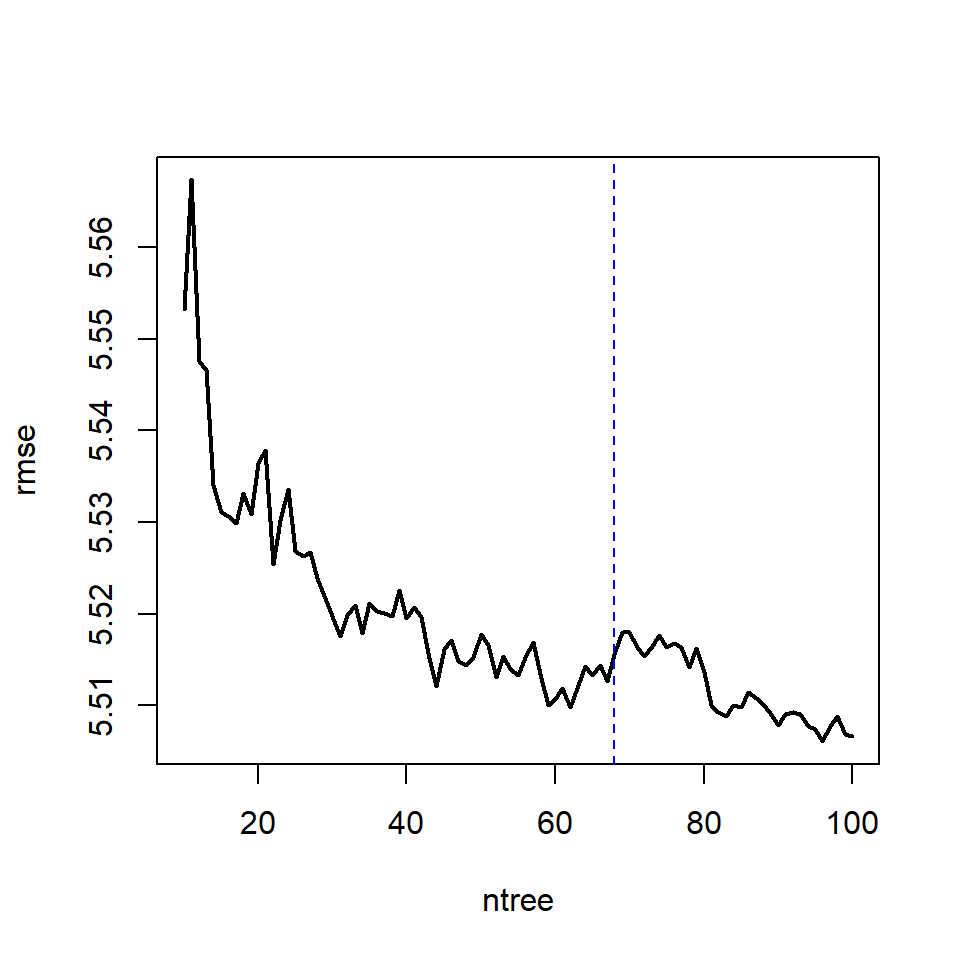

```
## integer(0)
```

```r
ntree <- 10:100
rmse <- vector(mode = "numeric", length = length(ntree))
for (i in seq_along(ntree)) {
  set.seed(123)

  model <- bagging(
    formula = Life ~.,
    data = train,
    coob = TRUE,
    nbagg = ntree[i]
  )
  rmse[i] <-model$err
}

plot(ntree, rmse, type = "l", lwd = 2) +
abline(v=68, col = "blue", lty = "dashed")
```

We can compare this result to our hyper_grid results that show 91 models can be used to review decision tree combinations.

We can validate our results once more with CARET.

```r
ctrl <- trainControl(method = "cv",  number = 10)

# CV bagged model
bagged_cv <- train(
  Life ~ .,
  data = train,
  method = "treebag",
  trControl = ctrl,
  importance = TRUE
  )
bagged_cv
```

```
## Bagged CART
##
## 1564 samples
##    9 predictor
##
## No pre-processing
## Resampling: Cross-Validated (10 fold)
## Summary of sample sizes: 1408, 1408, 1407, 1408, 1406, 1407, ...
## Resampling results:
##
##   RMSE      Rsquared   MAE
##   5.504375  0.6915304  4.221243
```

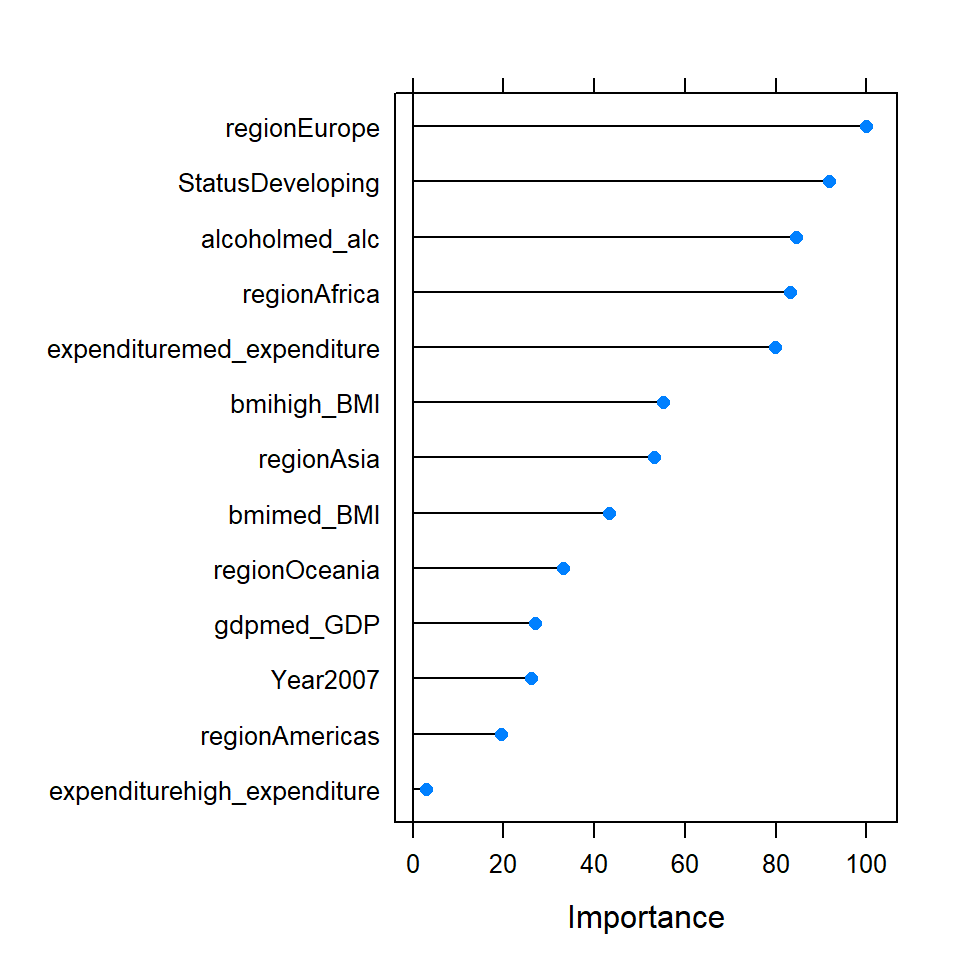

```r
plot(varImp(bagged_cv), 13)
```

```r
predct <- predict(bagged_cv, test)
RMSE(predct, test$Life)
```

```
## [1] 5.072404
```

Boosting:iteratively adds new models to the ensemble, each model tries to overcome the errors made by the previous model

# train$Life <- as.factor(train$Life)

ct <- boosting(formula = Life ~ ., data = train, boos = TRUE, mfinal=10, control = rpart.control(cp = -1))

ct1 <- boosting(formula = Life ~ ., data = train, boos = TRUE, mfinal=10, control = rpart.control(minsplit = 0))

# build model based on a forest of 750 trees and predict test data

```r
train$Life <- as.numeric(train$Life)
rfm <- randomForest(Life ~ ., train, ntree=750)

rfpred <- predict(rfm, test)

RMSE(rfpred, test$Life)
```

```
## [1] 4.787927
```

Another algorithm: Gradient boosting: classification and regression. like AdaBoost, but use gradient descent to address the current errors. Can overfit, so using cross-validation is very important (cv.folds)

```r
rfm <- gbm(Life ~ ., data=train, n.trees=150, cv.folds=3)
```

```
## Distribution not specified, assuming gaussian ...
```

```r
rfpred <- predict(rfm, test, n.trees=150)
RMSE(rfpred, test$Life)
```

```
## [1] 5.318405
```